# Introduction to facerec

# An Interface for Face Recognition in R

The facerec package provides an interface to the [Kairos Face Recognition API](https://www.kairos.com/docs/api/). The API detects faces in images and returns estimates for demographics like gender, ethnicity and age. It is also capable of recognizing and verifying humans across several images.

## How to Install

To install the CRAN version of facerec use `install.packages('facerec')`.

You can also download and install the latest development version of the app by running `devtools::install_github('methodds/facerec')`. For Windows users installing from github requires proper setup of [Rtools](https://cran.r-project.org/bin/windows/Rtools/), for which a tutorial is available [here](https://github.com/stan-dev/rstan/wiki/Install-Rtools-for-Windows).

## How to Use

### Authentification

After loading facerec you first need to initiate your authentification credentials. Kairos offers a [free plan](https://www.kairos.com/pricing) for API access. After signing up, you will receive an application id and an application key. Both credentials need to be set as environment variables before using the initialization function `facerec_init()`:

```r
Sys.setenv(kairos_id = "Your Kairos API id")
Sys.setenv(kairos_key = "Your Kairos API key")
```

```r
library(facerec)
facerec_init()
```

You only need to call `facerec_init()` once after loading the package. In order to avoid entering your credentials for each session, you can permanently store them in your `.Renviron`. I recommend `usethis::edit_r_environ()` to find and edit your environment file.

### Face Recognition

The Kairos API accepts image of file type JPG, PNG, or BMP. Images can be passed to several facerec functions, either as an url string or a local image prepared with `prep_image()`. In the following example, `detect()` is used to recognize the face of the Star Wars character Finn:

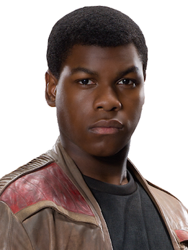

```r
finn_image <- 'https://upload.wikimedia.org/wikipedia/en/2/2a/Finn-Force_Awakens_%282015%29.png'
finn_face <- detect(image = finn_image)
```

The function returns a dataframe with annotations for the recognized face in the input image. Variables include positional features of recognized faces, such as x and y coordinates for eyes. Moreover, demographic attributes like gender, ethnicity and age are available.

Features can be visualized with the packages magick and ggplot2:

[figure not shown]

```r
library(magick)
library(ggplot2)
library(scales)

 finn_image %>% image_read() %>% image_ggplot() +
   geom_rect(data = finn_face,
             aes(xmin = top_left_x, xmax = top_left_x + width,
                 ymin = top_left_y, ymax = top_left_y + height),
             fill = NA, linetype = 'dashed', size = 2, color = '#377eb8') +
   geom_label(data = finn_face,
             aes(x = chin_tip_x, y = chin_tip_y + 20,
                 label = paste('Gender:',
                               percent(face_gender_male_confidence),
                 'Male')), size = 6, color = '#377eb8') +
   geom_label(data = finn_face,
             aes(x = chin_tip_x, y = chin_tip_y + 60,
                 label = paste('Ethnicity:', percent(face_black),
                 'Black')), size = 6, color = '#377eb8') +
   theme(legend.position="none")
```

Kairos has [some recommendations](https://www.kairos.com/docs/api/best-practices) to improve the quality of its recognition service, but in general, the API also works with multiple faces inside an image:

[figure not shown]

```r
sw_img <- "https://upload.wikimedia.org/wikipedia/en/8/82/Leiadeathstar.jpg"
sw_faces <- detect(sw_img)

sw_img %>% image_read() %>% image_ggplot() +
   geom_rect(data = sw_faces,
             aes(xmin = top_left_x , xmax =  top_left_x + width,
                 ymin = top_left_y, ymax = top_left_y + height,
                 color = factor(face_id)),
             fill = NA, linetype = 'dashed', size = 2) +
   geom_label(data = sw_faces,
             aes(x = chin_tip_x, y = chin_tip_y + 15,
                 label = face_gender_type,
                 color = factor(face_id)), size = 8) +
   theme(legend.position="none")
```

Besides annotating faces in single images, it is possible to permanently store face recognition data with the Kairos API. This allows to assign multiple images to subject ids and estimates about whether faces from different images belong to the same subjects:

```r
finn_face <- enroll(image = finn_image,
                    subject_id = 'finn', gallery = 'starwars')
finn_new <- 'https://upload.wikimedia.org/wikipedia/commons/b/b6/John_Boyega_by_Gage_Skidmore.jpg'
finn_rec <- recognize(image = finn_new, gallery = 'starwars',
                      show_candidate_images = FALSE)
```

The function `recognize()` returns a dataframe including the probability of a match in the column `confidence`.